# Linear_regression

Matthew Chen, Jasper Tsai, Mark Faynboym

2022-12-04

```r
library(MASS)
library(leaps)
library(caret)
# import data
df = read.csv('data/data_clean.csv')
# remove 'job_location' column
df = df[-4]

head(df)
```

```
##   avg_salary_k rating         size age python visual_software ML_software spark
## 1         72.0    3.8  501 - 1000   48      1               1           0     0
## 2         87.5    3.4      10000+   37      1               0           0     0
## 3         85.0    4.8  501 - 1000   11      1               0           0     1
## 4         76.5    3.8 1001 - 5000   56      1               0           0     0
## 5        114.5    2.9    51 - 200   23      1               0           0     0
## 6         95.0    3.4   201 - 500   21      1               1           0     0
##   aws excel sql sas hadoop degree in_CA senior_status
## 1   0     1   0   1      0     MS False         False
## 2   0     0   0   0      0     MS False         False
## 3   0     1   1   1      0     MS False         False
## 4   0     0   0   0      0  Other False         False
## 5   0     1   1   1      0  Other False         False
## 6   1     1   1   0      0  Other False         False
```

```r
# change categorical variables to R Factors
df$size = as.factor(df$size)
df$python = as.factor(df$python)
df$visual_software = as.factor(df$visual_software)
df$ML_software = as.factor(df$ML_software)
df$spark = as.factor(df$spark)
df$aws = as.factor(df$aws)
df$excel = as.factor(df$excel)
df$sql = as.factor(df$sql)
df$sas = as.factor(df$sas)
df$hadoop = as.factor(df$hadoop)
df$degree = as.factor(df$degree)
df$in_CA = as.factor(df$in_CA)
df$senior_status = as.factor(df$senior_status)
```

# No interaction

## model1: Linear model with all first order terms

Here we have p=22 n=433 observations. We have R2=0.3865 and R2a=0.3552.

```r
#Fit First order model with full data
model1 = lm(avg_salary_k~., data=df)
summary(model1)
```

```
##
## Call:
## lm(formula = avg_salary_k ~ ., data = df)
##
## Residuals:
##     Min      1Q  Median      3Q     Max
## -68.237 -19.300  -2.686  15.645 129.433
##
## Coefficients:
##                   Estimate Std. Error t value Pr(>|t|)
## (Intercept)       50.88530   14.00955   3.632 0.000317 ***
## rating             6.06497    2.71308   2.235 0.025924 *
## size10000+        10.23128    9.39165   1.089 0.276615
## size1001 - 5000    2.08715    8.96246   0.233 0.815973
## size201 - 500      1.76830    9.05893   0.195 0.845333
## size5001 - 10000  -5.66351    9.81860  -0.577 0.564381
## size501 - 1000     1.08277    9.02291   0.120 0.904540
## size51 - 200       3.65827    9.15903   0.399 0.689794
## age                0.07354    0.03402   2.162 0.031189 *
## python1           18.72444    3.26697   5.731 1.93e-08 ***
## visual_software1  -8.44936    3.85267  -2.193 0.028859 *
## ML_software1       6.97582    4.42777   1.575 0.115918
## spark1             0.62159    4.27003   0.146 0.884332
## aws1               5.06345    3.59485   1.409 0.159731
## excel1            -2.69535    2.94687  -0.915 0.360913
## sql1              -5.76717    3.49817  -1.649 0.099989 .
## sas1              16.69562    5.13433   3.252 0.001241 **
## hadoop1            6.00225    4.59322   1.307 0.192023
## degreeOther       -2.81089    3.33942  -0.842 0.400428
## degreePHD         10.11828    4.86816   2.078 0.038287 *
## in_CATrue         28.07331    3.68637   7.615 1.82e-13 ***
## senior_statusTrue 24.42671    3.27889   7.450 5.56e-13 ***
## ---
## Signif. codes:  0 '***' 0.001 '**' 0.01 '*' 0.05 '.' 0.1 ' ' 1
##
## Residual standard error: 29.35 on 411 degrees of freedom
## Multiple R-squared:  0.3865, Adjusted R-squared:  0.3552
## F-statistic: 12.33 on 21 and 411 DF,  p-value: < 2.2e-16
```

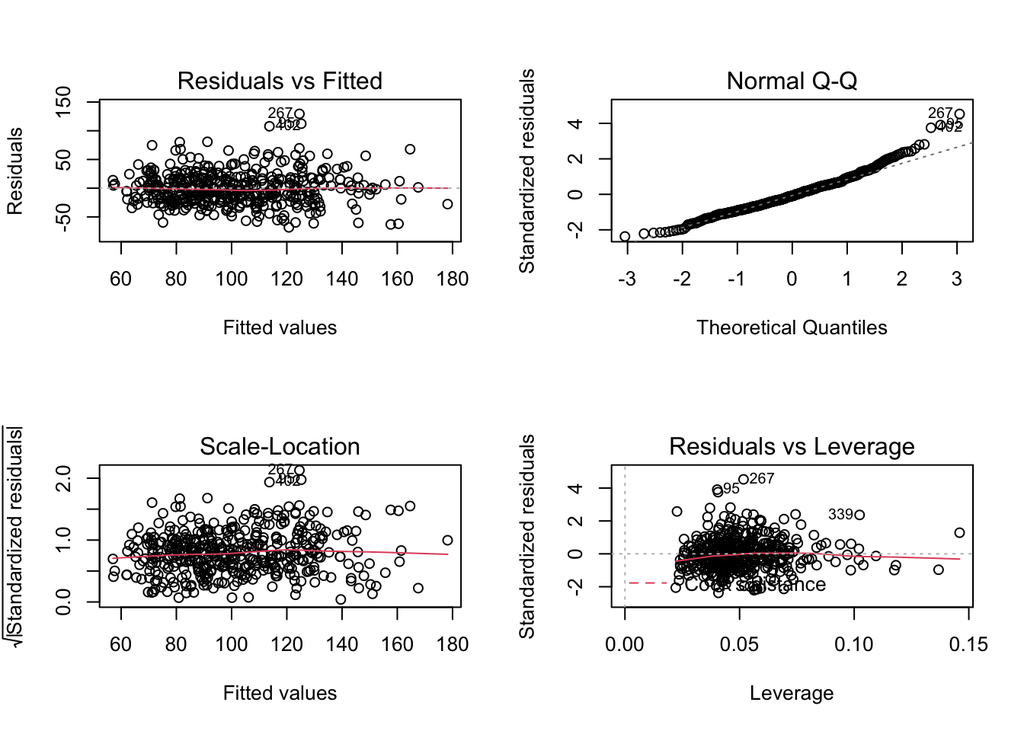

```r
# Model diagnostics
par(mfrow=c(2, 2))
plot(model1)
```

In the model diagnostics, we find that residuals have no pattern, are centered about zero, and have no sign of heteroskedasticity. In the normal-QQ plot, we find that there are heavy right tails, though this may be caused by outliers in Y (we will examine these later). Overall, this model is reasonable.

### Exploration of transformation in Y with original full data with model1

Since we have heavy tails in the residual distribution, we conduct the box-cox procedure to see if a transformation of the response variable would be beneficial.

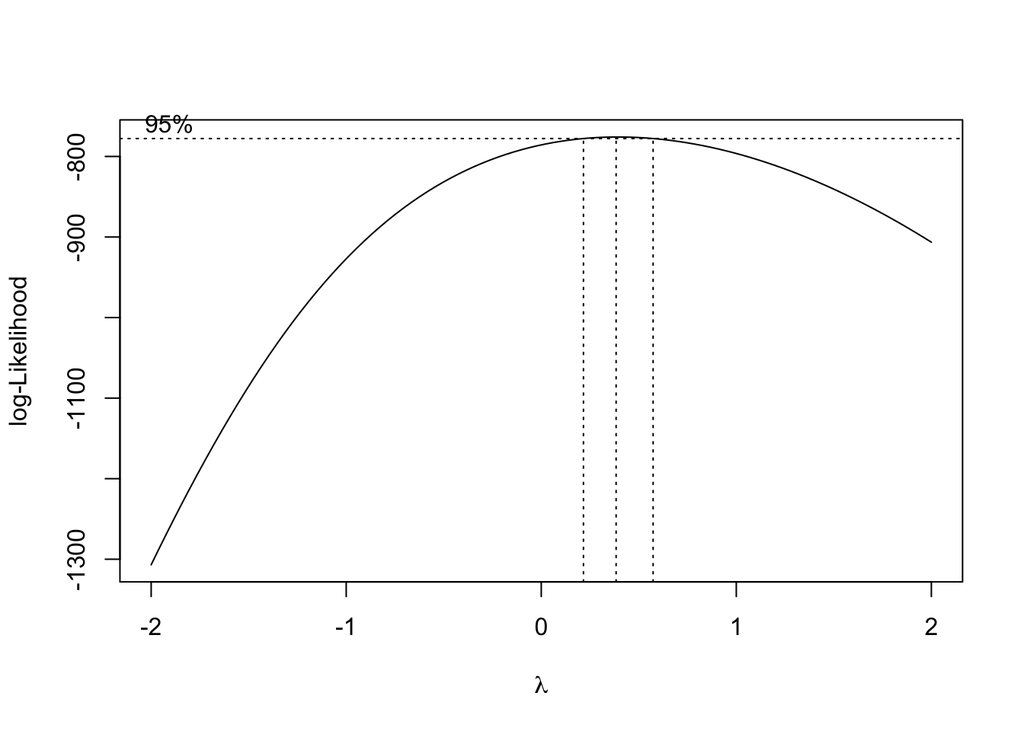

```r
boxcox(model1, data=df)
```

The Box-Cox suggests a square root transformation of the data  
**we will continue to use SQRT(Y) data for rest of this section**

## model1_sqrt: Refit model1 using a square root transform in Y

```r
#create new dataset called df_sqrtY with sqrt(Y) as avg_salary_k
df_sqrtY = df
df_sqrtY$avg_salary_k = sqrt(df$avg_salary_k)
```

Here we have p=22 n=433 observations. We have R2=0.3887 and R2a=0.3574.

```r
model1_sqrt = lm(avg_salary_k~., data=df_sqrtY)
summary(model1_sqrt)
```

```
##
## Call:
## lm(formula = avg_salary_k ~ ., data = df_sqrtY)
##
## Residuals:
##     Min      1Q  Median      3Q     Max
## -4.5815 -1.0102 -0.0118  0.8430  4.8772
##
## Coefficients:
##                    Estimate Std. Error t value Pr(>|t|)
## (Intercept)        7.618047   0.688072  11.072  < 2e-16 ***
## rating             0.261840   0.133252   1.965   0.0501 .
## size10000+         0.428366   0.461266   0.929   0.3536
## size1001 - 5000    0.018265   0.440187   0.041   0.9669
## size201 - 500      0.062090   0.444925   0.140   0.8891
## size5001 - 10000  -0.342500   0.482236  -0.710   0.4780
## size501 - 1000    -0.026790   0.443156  -0.060   0.9518
## size51 - 200       0.159912   0.449841   0.355   0.7224
## age                0.003654   0.001671   2.187   0.0293 *
## python1            0.950128   0.160456   5.921 6.74e-09 ***
## visual_software1  -0.398770   0.189222  -2.107   0.0357 *
## ML_software1       0.382377   0.217468   1.758   0.0794 .
## spark1             0.054051   0.209720   0.258   0.7967
## aws1               0.264160   0.176559   1.496   0.1354
## excel1            -0.168254   0.144734  -1.163   0.2457
## sql1              -0.263934   0.171811  -1.536   0.1253
## sas1               0.801324   0.252170   3.178   0.0016 **
## hadoop1            0.351854   0.225594   1.560   0.1196
## degreeOther       -0.171737   0.164014  -1.047   0.2957
## degreePHD          0.465469   0.239097   1.947   0.0522 .
## in_CATrue          1.317280   0.181054   7.276 1.76e-12 ***
## senior_statusTrue  1.195941   0.161041   7.426 6.50e-13 ***
## ---
## Signif. codes:  0 '***' 0.001 '**' 0.01 '*' 0.05 '.' 0.1 ' ' 1
##
## Residual standard error: 1.441 on 411 degrees of freedom
## Multiple R-squared:  0.3887, Adjusted R-squared:  0.3574
## F-statistic: 12.44 on 21 and 411 DF,  p-value: < 2.2e-16
```

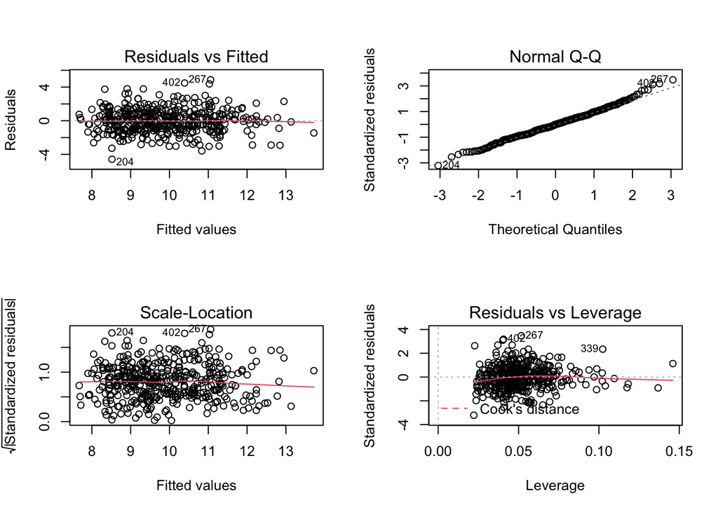

```r
# model diagnostics
par(mfrow=c(2, 2))
plot(model1_sqrt)
```

In the QQ plot we see that the distribution is much less heavy tailed than before, and R2 and R2a also remain mostly unchanged. Thus, these tails may be caused by a handful of outliers in Y. We continue using the square root transformation of our response variable.

## mordel1_sqrt_aic: AIC of model1_sqrt

We want to use AIC to see if we can get a better model

```r
fit0 = lm(avg_salary_k~1, data=df_sqrtY)
step.aic = stepAIC(fit0, scope=list(upper=model1_sqrt, lower=fit0), trace=FALSE)
step.aic$anova
```

```
## Stepwise Model Path
## Analysis of Deviance Table
##
## Initial Model:
## avg_salary_k ~ 1
##
## Final Model:
## avg_salary_k ~ senior_status + in_CA + python + degree + visual_software +
##     age + rating + sas + aws + ML_software + excel + hadoop
##
##
##                 Step Df   Deviance Resid. Df Resid. Dev      AIC
## 1                                        432  1396.8593 509.1486
## 2    + senior_status  1 162.064783       431  1234.7945 457.7503
## 3            + in_CA  1 135.443012       430  1099.3515 409.4426
## 4           + python  1 100.779407       429   998.5721 369.8099
## 5           + degree  2  38.304043       427   960.2680 356.8736
## 6  + visual_software  1  21.200060       426   939.0680 349.2070
## 7              + age  1  12.259848       425   926.8081 345.5168
## 8           + rating  1  13.826643       424   912.9815 341.0084
## 9              + sas  1  12.537375       423   900.4441 337.0211
## 10             + aws  1   8.764848       422   891.6793 334.7857
## 11     + ML_software  1   6.321882       421   885.3574 333.7048
## 12           + excel  1   5.194225       420   880.1632 333.1570
## 13          + hadoop  1   4.535710       419   875.6275 332.9199
```

### fit model1_sqrt_aic from aic criterion

We have R2=0.3731 and R2a=0.3537.

```r
# fit the selected model
model1_sqrt_aic = lm(avg_salary_k ~ senior_status + in_CA + python + degree + visual_software +
    age + rating + sas + aws + ML_software + excel + hadoop, data=df_sqrtY)
summary(model1_sqrt_aic)
```

```
##
## Call:
## lm(formula = avg_salary_k ~ senior_status + in_CA + python +
##     degree + visual_software + age + rating + sas + aws + ML_software +
##     excel + hadoop, data = df_sqrtY)
##
## Residuals:
##     Min      1Q  Median      3Q     Max
## -4.5073 -1.0019 -0.0474  0.8845  5.3912
##
## Coefficients:
##                    Estimate Std. Error t value Pr(>|t|)
## (Intercept)        7.571750   0.509438  14.863  < 2e-16 ***
## senior_statusTrue  1.176426   0.159886   7.358 9.94e-13 ***
## in_CATrue          1.336426   0.177818   7.516 3.46e-13 ***
## python1            0.892674   0.153550   5.814 1.21e-08 ***
## degreeOther       -0.253177   0.160222  -1.580  0.11482
## degreePHD          0.518695   0.237088   2.188  0.02924 *
## visual_software1  -0.471865   0.178314  -2.646  0.00845 **
## age                0.003973   0.001403   2.831  0.00487 **
## rating             0.291113   0.127873   2.277  0.02332 *
## sas1               0.688045   0.243152   2.830  0.00488 **
## aws1               0.276283   0.173449   1.593  0.11194
## ML_software1       0.369007   0.214853   1.717  0.08663 .
## excel1            -0.228131   0.142927  -1.596  0.11121
## hadoop1            0.286885   0.194732   1.473  0.14144
## ---
## Signif. codes:  0 '***' 0.001 '**' 0.01 '*' 0.05 '.' 0.1 ' ' 1
##
## Residual standard error: 1.446 on 419 degrees of freedom
## Multiple R-squared:  0.3731, Adjusted R-squared:  0.3537
## F-statistic: 19.19 on 13 and 419 DF,  p-value: < 2.2e-16
```

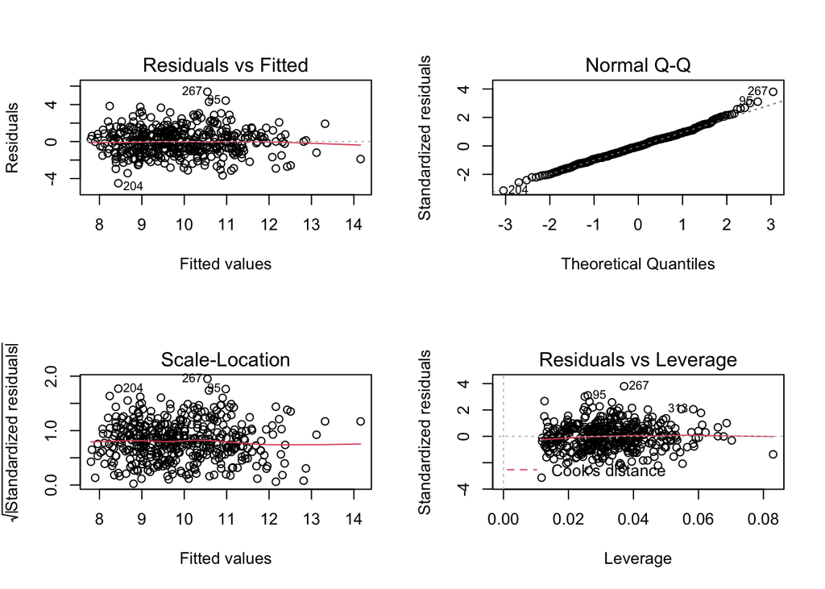

```r
# model diagnostics
par(mfrow=c(2, 2))
plot(model1_sqrt_aic)
```

The model is valid.

# Interaction

## model2: inclusion of all two-way interaction terms

Since R2 is low in Model 1, we attempt to fit a second order model with all interaction terms in an attempt to gain a better fit of the data.

```r
# Second order interaction model
model2 = lm(avg_salary_k~(.)^2, data=df)
summary(model2)
```

```
##
## Call:
## lm(formula = avg_salary_k ~ (.)^2, data = df)
##
## Residuals:
##     Min      1Q  Median      3Q     Max
## -68.012 -11.859   0.371  12.636  85.550
##
## Coefficients: (5 not defined because of singularities)
##                                       Estimate Std. Error t value Pr(>|t|)
## (Intercept)                         -5.869e+02  6.310e+02  -0.930 0.353283
## rating                               1.149e+02  1.354e+02   0.848 0.397286
## size10000+                           5.542e+02  6.303e+02   0.879 0.380259
## size1001 - 5000                      5.715e+02  6.291e+02   0.908 0.364620
## size201 - 500                        6.052e+02  6.271e+02   0.965 0.335541
## size5001 - 10000                     4.910e+02  6.310e+02   0.778 0.437326
## size501 - 1000                       5.818e+02  6.284e+02   0.926 0.355544
## size51 - 200                         6.577e+02  6.259e+02   1.051 0.294540
## age                                  5.499e+00  7.319e+00   0.751 0.453191
## python1                              2.378e+02  2.751e+02   0.864 0.388256
## visual_software1                     7.977e+01  7.717e+01   1.034 0.302411
## ML_software1                        -3.098e+02  3.493e+02  -0.887 0.376064
## spark1                               2.009e+02  9.485e+01   2.118 0.035275 *
## aws1                                 3.499e+02  2.996e+02   1.168 0.244191
## excel1                               1.215e+02  1.153e+02   1.054 0.293203
## sql1                                -1.336e+02  9.701e+01  -1.378 0.169697
## sas1                                -1.287e+00  2.026e+02  -0.006 0.994940
## hadoop1                             -5.568e+01  8.282e+01  -0.672 0.502081
## degreeOther                         -6.798e+01  1.336e+02  -0.509 0.611453
## degreePHD                           -9.726e+00  6.038e+01  -0.161 0.872173
## in_CATrue                           -7.889e+01  4.694e+01  -1.681 0.094211 .
## senior_statusTrue                    7.052e+01  4.247e+01   1.660 0.098229 .
## rating:size10000+                   -8.437e+01  1.356e+02  -0.622 0.534380
## rating:size1001 - 5000              -9.238e+01  1.350e+02  -0.684 0.494408
## rating:size201 - 500                -9.815e+01  1.345e+02  -0.729 0.466471
## rating:size5001 - 10000             -7.522e+01  1.359e+02  -0.553 0.580493
## rating:size501 - 1000               -9.432e+01  1.348e+02  -0.700 0.484729
## rating:size51 - 200                 -1.048e+02  1.344e+02  -0.780 0.436175
## rating:age                          -1.856e-01  1.597e-01  -1.162 0.246583
## rating:python1                      -3.157e+00  8.995e+00  -0.351 0.725948
```

[output cut: 177 more lines]

```
## hadoop1:degreeOther                  1.879e+01  1.811e+01   1.038 0.300598
## hadoop1:degreePHD                   -2.038e+01  4.886e+01  -0.417 0.677019
## hadoop1:in_CATrue                   -2.450e+01  1.973e+01  -1.242 0.215545
## hadoop1:senior_statusTrue           -2.002e+00  1.472e+01  -0.136 0.891928
## degreeOther:in_CATrue                1.635e+00  1.366e+01   0.120 0.904810
## degreePHD:in_CATrue                 -2.928e+01  1.901e+01  -1.540 0.124910
## degreeOther:senior_statusTrue        1.088e+01  1.140e+01   0.954 0.341150
## degreePHD:senior_statusTrue         -1.475e+01  1.467e+01  -1.005 0.316028
## in_CATrue:senior_statusTrue          1.386e+01  1.309e+01   1.059 0.290835
## ---
## Signif. codes:  0 '***' 0.001 '**' 0.01 '*' 0.05 '.' 0.1 ' ' 1
##
## Residual standard error: 29.38 on 222 degrees of freedom
## Multiple R-squared:  0.6679, Adjusted R-squared:  0.3538
## F-statistic: 2.126 on 210 and 222 DF,  p-value: 1.998e-08
```

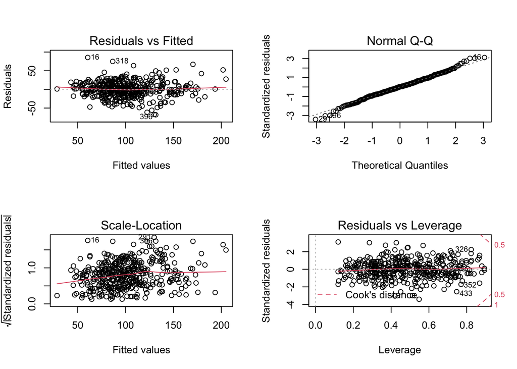

```r
# model diagnostics
par(mfrow=c(2, 2))
plot(model2)
```

In the model diagnostics, we find that residuals have no pattern, are centered about zero, and have no sign of heteroskedasticity. In the normal-QQ plot, we find that there are some right tails, though this may be caused by outliers in Y (we will examine these later). Overall, this model is reasonable.

### Exploration of transformation in Y with original full data with model2

Since we have tails in the residual distribution, we conduct the box-cox procedure to see if a transformation of the response variable would be beneficial.

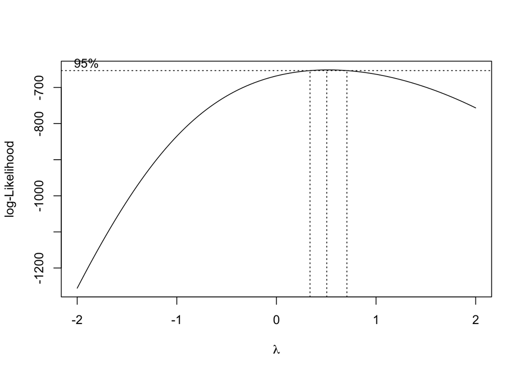

```r
boxcox(model2, data=df)
```

The Box-Cox suggests a square root transformation of the data **we will continue to use SQRT(Y) data for rest of this section**

## model2_sqrt: Refit model2 using a square root transform in Y

We have R2 = 0.6571, R2a = 0.3328

```r
# Second order interaction model
model2_sqrt = lm(avg_salary_k~(.)^2, data=df_sqrtY)
summary(model2_sqrt)
```

```
##
## Call:
## lm(formula = avg_salary_k ~ (.)^2, data = df_sqrtY)
##
## Residuals:
##     Min      1Q  Median      3Q     Max
## -3.7335 -0.5854  0.0000  0.6470  4.4827
##
## Coefficients: (5 not defined because of singularities)
##                                       Estimate Std. Error t value Pr(>|t|)
## (Intercept)                         -2.825e+01  3.154e+01  -0.896 0.371380
## rating                               6.709e+00  6.770e+00   0.991 0.322784
## size10000+                           3.037e+01  3.151e+01   0.964 0.336224
## size1001 - 5000                      3.186e+01  3.145e+01   1.013 0.312179
## size201 - 500                        3.306e+01  3.135e+01   1.055 0.292735
## size5001 - 10000                     2.663e+01  3.155e+01   0.844 0.399481
## size501 - 1000                       3.224e+01  3.142e+01   1.026 0.305914
## size51 - 200                         3.552e+01  3.129e+01   1.135 0.257551
## age                                  2.990e-01  3.659e-01   0.817 0.414657
## python1                              1.262e+01  1.375e+01   0.918 0.359653
## visual_software1                     3.480e+00  3.858e+00   0.902 0.368048
## ML_software1                        -1.711e+01  1.746e+01  -0.980 0.328276
## spark1                               9.568e+00  4.742e+00   2.018 0.044815 *
## aws1                                 1.938e+01  1.498e+01   1.294 0.197177
## excel1                               6.526e+00  5.763e+00   1.132 0.258686
## sql1                                -6.627e+00  4.850e+00  -1.366 0.173210
## sas1                                -1.948e+00  1.013e+01  -0.192 0.847653
## hadoop1                             -3.043e+00  4.141e+00  -0.735 0.463107
## degreeOther                         -3.815e+00  6.681e+00  -0.571 0.568561
## degreePHD                            2.038e-02  3.019e+00   0.007 0.994619
## in_CATrue                           -3.149e+00  2.346e+00  -1.342 0.180900
## senior_statusTrue                    3.684e+00  2.123e+00   1.735 0.084076 .
## rating:size10000+                   -4.882e+00  6.778e+00  -0.720 0.472050
## rating:size1001 - 5000              -5.481e+00  6.748e+00  -0.812 0.417491
## rating:size201 - 500                -5.652e+00  6.726e+00  -0.840 0.401680
## rating:size5001 - 10000             -4.364e+00  6.794e+00  -0.642 0.521336
## rating:size501 - 1000               -5.459e+00  6.737e+00  -0.810 0.418666
## rating:size51 - 200                 -5.915e+00  6.717e+00  -0.881 0.379466
## rating:age                          -1.196e-02  7.986e-03  -1.498 0.135546
## rating:python1                      -3.018e-01  4.497e-01  -0.671 0.502801
```

[output cut: 177 more lines]

```
## hadoop1:degreeOther                  1.057e+00  9.052e-01   1.168 0.244169
## hadoop1:degreePHD                   -6.710e-01  2.443e+00  -0.275 0.783805
## hadoop1:in_CATrue                   -1.127e+00  9.861e-01  -1.143 0.254158
## hadoop1:senior_statusTrue           -6.499e-02  7.360e-01  -0.088 0.929713
## degreeOther:in_CATrue                1.453e-01  6.829e-01   0.213 0.831754
## degreePHD:in_CATrue                 -1.340e+00  9.502e-01  -1.410 0.159839
## degreeOther:senior_statusTrue        5.791e-01  5.700e-01   1.016 0.310749
## degreePHD:senior_statusTrue         -6.692e-01  7.336e-01  -0.912 0.362591
## in_CATrue:senior_statusTrue          5.486e-01  6.544e-01   0.838 0.402700
## ---
## Signif. codes:  0 '***' 0.001 '**' 0.01 '*' 0.05 '.' 0.1 ' ' 1
##
## Residual standard error: 1.469 on 222 degrees of freedom
## Multiple R-squared:  0.6571, Adjusted R-squared:  0.3328
## F-statistic: 2.026 on 210 and 222 DF,  p-value: 1.329e-07
```

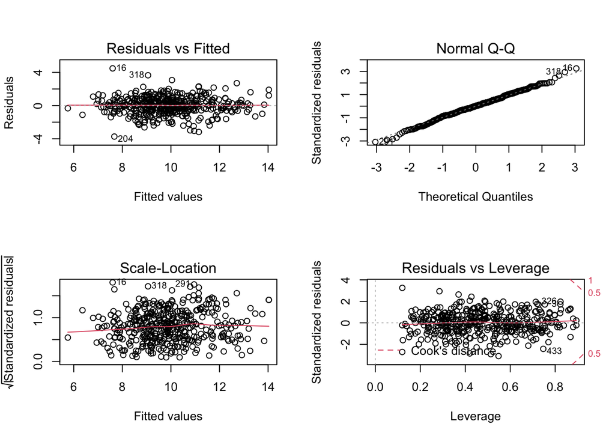

```r
# model diagnostics
par(mfrow=c(2, 2))
plot(model2_sqrt)
```

Here we have p=211 regression coefficients. While the multiple R2 has increased significantly, the adjusted R2 has not changed by much (due to the drastic decrease in degrees of freedom). However, we realize that most of the terms are not significant so we attempt to fit a smaller subset of model2_sqrt using stepwise regression.

## model2_sqrt_aic: AIC of model2_sqrt

```r
fit0 = lm(avg_salary_k~1, data=df_sqrtY)
step.aic = stepAIC(fit0, scope=list(upper=model2_sqrt, lower=fit0), trace=FALSE)
step.aic$anova
```

```
## Stepwise Model Path
## Analysis of Deviance Table
##
## Initial Model:
## avg_salary_k ~ 1
##
## Final Model:
## avg_salary_k ~ senior_status + in_CA + python + degree + visual_software +
##     age + rating + sas + aws + ML_software + hadoop + sql + python:aws +
##     in_CA:ML_software + age:ML_software + age:rating + python:rating +
##     visual_software:hadoop + python:hadoop + sas:sql
##
##
##                        Step Df   Deviance Resid. Df Resid. Dev      AIC
## 1                                               432  1396.8593 509.1486
## 2           + senior_status  1 162.064783       431  1234.7945 457.7503
## 3                   + in_CA  1 135.443012       430  1099.3515 409.4426
## 4                  + python  1 100.779407       429   998.5721 369.8099
## 5                  + degree  2  38.304043       427   960.2680 356.8736
## 6         + visual_software  1  21.200060       426   939.0680 349.2070
## 7                     + age  1  12.259848       425   926.8081 345.5168
## 8                  + rating  1  13.826643       424   912.9815 341.0084
## 9                     + sas  1  12.537375       423   900.4441 337.0211
## 10                    + aws  1   8.764848       422   891.6793 334.7857
## 11             + python:aws  1   7.097963       421   884.5813 333.3251
## 12            + ML_software  1   6.270283       420   878.3110 332.2449
## 13      + ML_software:in_CA  1   9.998189       419   868.3128 329.2876
## 14        + age:ML_software  1   5.446500       418   862.8663 328.5631
## 15                  + excel  1   5.042879       417   857.8235 328.0250
## 16             + rating:age  1   4.824547       416   852.9989 327.5829
## 17          + rating:python  1   4.698548       415   848.3004 327.1912
## 18                 + hadoop  1   4.288238       414   844.0121 326.9968
## 19 + visual_software:hadoop  1   5.712531       413   838.2996 326.0562
## 20          + python:hadoop  1   5.514417       412   832.7852 325.1985
## 21                    + sql  1   4.068588       411   828.7166 325.0778
## 22                + sql:sas  1   6.865174       410   821.8514 323.4759
## 23                  - excel  1   3.346980       411   825.1984 323.2357
```

We have R2 = 0.4092, R2a = 0.3791

```r
# fit selected model
model2_sqrt_aic = lm(avg_salary_k ~ senior_status + in_CA + python + degree + visual_software +
    age + rating + sas + aws + ML_software + hadoop + sql + python:aws +
    in_CA:ML_software + age:ML_software + age:rating + python:rating +
    visual_software:hadoop + python:hadoop + sas:sql, data=df_sqrtY)
summary(model2_sqrt_aic)
```

```
##
## Call:
## lm(formula = avg_salary_k ~ senior_status + in_CA + python +
##     degree + visual_software + age + rating + sas + aws + ML_software +
##     hadoop + sql + python:aws + in_CA:ML_software + age:ML_software +
##     age:rating + python:rating + visual_software:hadoop + python:hadoop +
##     sas:sql, data = df_sqrtY)
##
## Residuals:
##     Min      1Q  Median      3Q     Max
## -4.5140 -0.8801  0.0026  0.9061  4.4492
##
## Coefficients:
##                           Estimate Std. Error t value Pr(>|t|)
## (Intercept)               5.876354   0.865080   6.793 3.87e-11 ***
## senior_statusTrue         1.209110   0.158084   7.649 1.46e-13 ***
## in_CATrue                 1.585530   0.192990   8.216 2.78e-15 ***
## python1                   2.573401   0.958289   2.685  0.00754 **
## degreeOther              -0.223158   0.159973  -1.395  0.16378
## degreePHD                 0.574757   0.238056   2.414  0.01620 *
## visual_software1         -0.607935   0.203312  -2.990  0.00296 **
## age                       0.029976   0.014968   2.003  0.04587 *
## rating                    0.686972   0.229374   2.995  0.00291 **
## sas1                      1.736194   0.601294   2.887  0.00409 **
## aws1                      0.794445   0.294290   2.700  0.00723 **
## ML_software1              1.002828   0.321239   3.122  0.00192 **
## hadoop1                   0.727856   0.409442   1.778  0.07620 .
## sql1                     -0.184384   0.173065  -1.065  0.28732
## python1:aws1             -0.706984   0.362891  -1.948  0.05207 .
## in_CATrue:ML_software1   -1.183797   0.464795  -2.547  0.01123 *
## age:ML_software1         -0.007241   0.004431  -1.634  0.10303
## age:rating               -0.007133   0.004068  -1.753  0.08028 .
## python1:rating           -0.377096   0.254662  -1.481  0.13943
## visual_software1:hadoop1  0.721045   0.407674   1.769  0.07769 .
## python1:hadoop1          -0.798905   0.457253  -1.747  0.08135 .
## sas1:sql1                -1.238629   0.653602  -1.895  0.05878 .
## ---
## Signif. codes:  0 '***' 0.001 '**' 0.01 '*' 0.05 '.' 0.1 ' ' 1
##
## Residual standard error: 1.417 on 411 degrees of freedom
## Multiple R-squared:  0.4092, Adjusted R-squared:  0.3791
## F-statistic: 13.56 on 21 and 411 DF,  p-value: < 2.2e-16
```

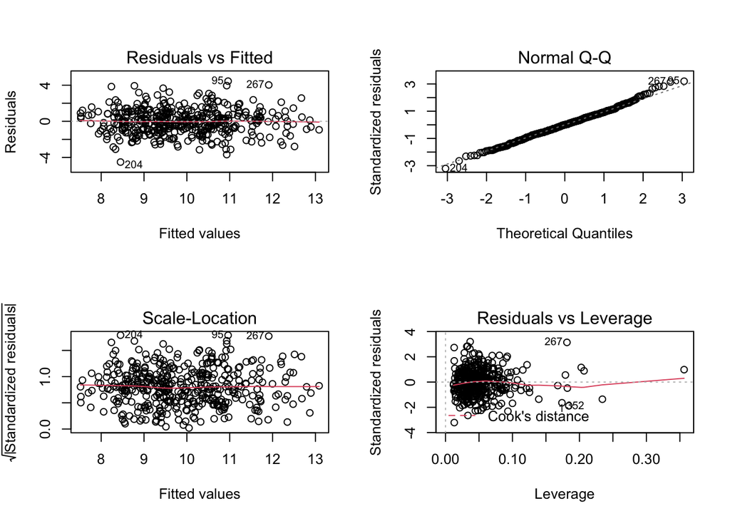

```r
# model diagnostics
par(mfrow=c(2, 2))
plot(model2_sqrt_aic)
```

The model is valid.

# Analysis of Outliers

**We will continue to do the rest of the outlier analysis with model2_sqrt_aic** In the residual plots above, we notice points that are potentially outlying in Y and are creating heavy tails in the residual distribution…

## Bonferroni Outlier test (Outliers in Y)

```r
#Bonferonni outlier test
require(car)
# return
outlierTest(model2_sqrt_aic,cutoff=0.05,nmax=15)
```

```
## No Studentized residuals with Bonferroni p < 0.05
## Largest |rstudent|:
##      rstudent unadjusted p-value Bonferroni p
## 204 -3.243639          0.0012768      0.55284
```

```r
#Cook's distance
library(base)
Cookvalue=4/(length(df_sqrtY$avg_salary_k*summary(model2_sqrt_aic)$df[2])) #Cook's distance threshold model 2
paste("Cook's distance value is :", Cookvalue)
```

```
## [1] "Cook's distance value is : 0.0092378752886836"
```

```r
cooks.distance(model2_sqrt_aic)[204] #Cook's distance for our outlier from the Bonferonni test
```

```
##         204
## 0.006186943
```

There is NO influential cases for outlying in Y

## Leverage (Outliers in X)

```r
# check for points outlying in X
leverage = influence(model2_sqrt_aic)$hat # leverage values
list=leverage[leverage > 2*length(model2_sqrt_aic$coefficients)/length(model2_sqrt_aic$residuals)] #outliers in X
list
```

```
##         1        15        55        68       107       141       152       187
## 0.1841930 0.3563417 0.1074207 0.1819521 0.1046143 0.2068692 0.1252859 0.2342894
##       212       215       225       260       267       296       298       299
## 0.1127623 0.1676668 0.1206586 0.1217278 0.1813573 0.1253828 0.1154702 0.1790692
##       313       328       352       372       389       421
## 0.2026876 0.1054778 0.1739021 0.1134065 0.1032325 0.1393075
```

```r
#Cook's distance
Cooks_distances=cooks.distance(model2_sqrt_aic)[attributes(list)$names] #
High_influence_vars=Cooks_distances[Cooks_distances>Cookvalue]
High_influence_vars
```

```
##           1          15         141         187         260         267
## 0.036331415 0.024279688 0.009383891 0.025682051 0.011752432 0.099361917
##         313         352         421
## 0.015416387 0.025748230 0.013538092
```

High influential cases from outlying in X are identified.

## Remove outliers identified that are influential

We try to refit model2_sqrt_aic after removing the outlier  
new dataframe called **df_out** that uses df_sqrtY and remove outliers from that dataframe

```r
# remove outliers from df_sqrtY and create new df_out
df_out = df_sqrtY[-c(as.numeric(attributes(High_influence_vars)$names)), ]
head(df_out)
```

```
##   avg_salary_k rating         size age python visual_software ML_software spark
## 2     9.354143    3.4      10000+   37      1               0           0     0
## 3     9.219544    4.8  501 - 1000   11      1               0           0     1
## 4     8.746428    3.8 1001 - 5000   56      1               0           0     0
## 5    10.700467    2.9    51 - 200   23      1               0           0     0
## 6     9.746794    3.4   201 - 500   21      1               1           0     0
## 7     8.573214    4.1  501 - 1000   13      0               0           0     0
##   aws excel sql sas hadoop degree in_CA senior_status
## 2   0     0   0   0      0     MS False         False
## 3   0     1   1   1      0     MS False         False
## 4   0     0   0   0      0  Other False         False
## 5   0     1   1   1      0  Other False         False
## 6   1     1   1   0      0  Other False         False
## 7   0     1   0   0      0  Other False         False
```

## model2_sqrt_aic_out: Directly refit model2_sqrt_aic onto data without outliers

p = 22, n = 424, R2 = 0.4117, R2a = 0.381

```r
model2_sqrt_aic_out = lm(avg_salary_k ~ senior_status + in_CA + python + degree + visual_software +
    age + rating + sas + aws + ML_software + hadoop + sql + python:aws +
    in_CA:ML_software + age:ML_software + age:rating + python:rating +
    visual_software:hadoop + python:hadoop + sas:sql, data = df_out)
summary = summary(model2_sqrt_aic_out)
summary
```

```
##
## Call:
## lm(formula = avg_salary_k ~ senior_status + in_CA + python +
##     degree + visual_software + age + rating + sas + aws + ML_software +
##     hadoop + sql + python:aws + in_CA:ML_software + age:ML_software +
##     age:rating + python:rating + visual_software:hadoop + python:hadoop +
##     sas:sql, data = df_out)
##
## Residuals:
##     Min      1Q  Median      3Q     Max
## -4.5567 -0.8897  0.0012  0.8643  4.3200
##
## Coefficients:
##                           Estimate Std. Error t value Pr(>|t|)
## (Intercept)               6.244234   0.861244   7.250 2.15e-12 ***
## senior_statusTrue         1.249977   0.157140   7.955 1.85e-14 ***
## in_CATrue                 1.594628   0.191053   8.347 1.14e-15 ***
## python1                   2.495199   0.949534   2.628 0.008923 **
## degreeOther              -0.233769   0.158646  -1.474 0.141393
## degreePHD                 0.466519   0.240680   1.938 0.053282 .
## visual_software1         -0.551567   0.201633  -2.735 0.006504 **
## age                       0.020052   0.015187   1.320 0.187476
## rating                    0.609791   0.228560   2.668 0.007940 **
## sas1                      2.384939   1.407004   1.695 0.090841 .
## aws1                      0.765368   0.295652   2.589 0.009982 **
## ML_software1              1.171472   0.339264   3.453 0.000613 ***
## hadoop1                   0.755939   0.430062   1.758 0.079552 .
## sql1                     -0.259689   0.171894  -1.511 0.131638
## python1:aws1             -0.705968   0.362511  -1.947 0.052178 .
## in_CATrue:ML_software1   -1.223246   0.458751  -2.666 0.007975 **
## age:ML_software1         -0.012591   0.005913  -2.129 0.033835 *
## age:rating               -0.004652   0.004127  -1.127 0.260283
## python1:rating           -0.358031   0.252850  -1.416 0.157555
## visual_software1:hadoop1  0.714515   0.403397   1.771 0.077277 .
## python1:hadoop1          -0.832109   0.472214  -1.762 0.078805 .
## sas1:sql1                -1.853342   1.429958  -1.296 0.195691
## ---
## Signif. codes:  0 '***' 0.001 '**' 0.01 '*' 0.05 '.' 0.1 ' ' 1
##
## Residual standard error: 1.393 on 402 degrees of freedom
## Multiple R-squared:  0.4117, Adjusted R-squared:  0.381
## F-statistic:  13.4 on 21 and 402 DF,  p-value: < 2.2e-16
```

### Anova of model2_sqrt_aic_out

```r
anova(model2_sqrt_aic_out)
```

```
## Analysis of Variance Table
##
## Response: avg_salary_k
##                         Df Sum Sq Mean Sq F value    Pr(>F)
## senior_status            1 167.91 167.909 86.5714 < 2.2e-16 ***
## in_CA                    1 147.48 147.479 76.0379 < 2.2e-16 ***
## python                   1  90.74  90.738 46.7832 2.964e-11 ***
## degree                   2  27.63  13.815  7.1227 0.0009125 ***
## visual_software          1  17.62  17.622  9.0859 0.0027391 **
## age                      1   5.01   5.010  2.5832 0.1087866
## rating                   1  15.46  15.458  7.9702 0.0049918 **
## sas                      1   6.96   6.962  3.5897 0.0588564 .
## aws                      1   7.06   7.059  3.6394 0.0571406 .
## ML_software              1   7.22   7.221  3.7233 0.0543621 .
## hadoop                   1   3.80   3.802  1.9603 0.1622563
## sql                      1   4.19   4.186  2.1583 0.1425822
## python:aws               1   7.25   7.253  3.7394 0.0538465 .
## in_CA:ML_software        1   8.94   8.938  4.6084 0.0324133 *
## age:ML_software          1   6.83   6.827  3.5201 0.0613530 .
## age:rating               1   1.50   1.502  0.7746 0.3793257
## python:rating            1   5.60   5.600  2.8870 0.0900693 .
## visual_software:hadoop   1   5.20   5.199  2.6805 0.1023658
## python:hadoop            1   6.06   6.056  3.1225 0.0779792 .
## sas:sql                  1   3.26   3.258  1.6798 0.1956909
## Residuals              402 779.70   1.940
## ---
## Signif. codes:  0 '***' 0.001 '**' 0.01 '*' 0.05 '.' 0.1 ' ' 1
```

### Model diagnostics

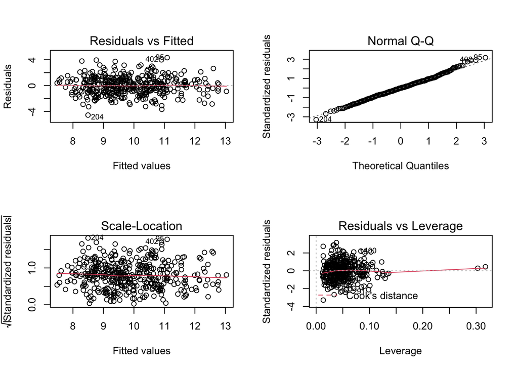

```r
par(mfrow=c(2, 2))
plot(model2_sqrt_aic_out)
```

```r
#Confidence Interval
Estimate = summary$coefficients[,1]
n=length(df_out$avg_salary_k)
s=summary$coefficients[,2]
margin = s*qt(0.975,df=n-2)
Lower_Bound = Estimate-s
Upper_Bound =Estimate+s
Confidence_Intervals=round(cbind(Lower_Bound,Estimate,Upper_Bound),3)
Confidence_Intervals
```

```
##                          Lower_Bound Estimate Upper_Bound
## (Intercept)                    5.383    6.244       7.105
## senior_statusTrue              1.093    1.250       1.407
## in_CATrue                      1.404    1.595       1.786
## python1                        1.546    2.495       3.445
## degreeOther                   -0.392   -0.234      -0.075
## degreePHD                      0.226    0.467       0.707
## visual_software1              -0.753   -0.552      -0.350
## age                            0.005    0.020       0.035
## rating                         0.381    0.610       0.838
## sas1                           0.978    2.385       3.792
## aws1                           0.470    0.765       1.061
## ML_software1                   0.832    1.171       1.511
## hadoop1                        0.326    0.756       1.186
## sql1                          -0.432   -0.260      -0.088
## python1:aws1                  -1.068   -0.706      -0.343
## in_CATrue:ML_software1        -1.682   -1.223      -0.764
## age:ML_software1              -0.019   -0.013      -0.007
## age:rating                    -0.009   -0.005      -0.001
## python1:rating                -0.611   -0.358      -0.105
## visual_software1:hadoop1       0.311    0.715       1.118
## python1:hadoop1               -1.304   -0.832      -0.360
## sas1:sql1                     -3.283   -1.853      -0.423
```

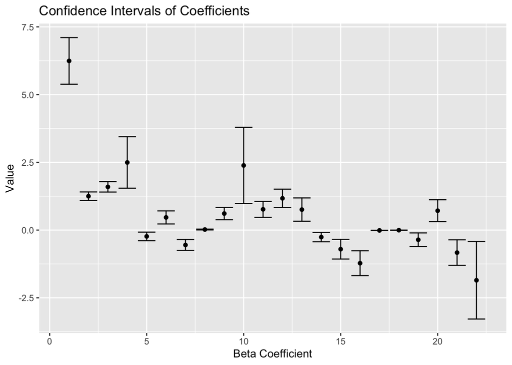

```r
x=1:length(Estimate)
data=data.frame(x,Estimate)

require(ggplot2)
ggplot(data,aes(x=x, y=Estimate)) + geom_point() + geom_errorbar(aes(ymin = Lower_Bound, ymax = Upper_Bound)) + labs(title="Confidence Intervals of Coefficients",
       x="Beta Coefficient",
       y="Value")
```

## Calculate Pressp for final selected model, model2_sqrt_aci_out

```r
# Press P
LOOCV = train(avg_salary_k ~ senior_status + in_CA + python + degree + visual_software +
    age + rating + sas + aws + ML_software + hadoop + sql + python:aws +
    in_CA:ML_software + age:ML_software + age:rating + python:rating +
    visual_software:hadoop + python:hadoop + sas:sql, data = df_out, method = "lm", trControl = trainControl(method = "LOOCV"))
MSE_LOOCV=as.numeric(LOOCV$results[2]^2)
PressP=MSE_LOOCV*n
PressP
```

```
## [1] 861.9258
```

```r
SSE=summary(model2_sqrt_aic_out)$sigma^2*n
SSE
```

```
## [1] 822.3661
```